# Lab 5: Generalized Linear Regression

Hao Wang

March 09, 2017

# 1. Load essential packages

```r
library(VGAM)
library(car)
library(MASS)
library(effects)
library(nnet) #neural net package, which contains multinomial function
library(ggplot2)
library(Zelig)
library(ZeligChoice)
```

# 2. Binary Dependent Variable

When our dependent variable is binary, OLS is not applicable due to the violation of the residual variance. Generally we have two different models: probit and logit. They share the same idea: coerce the predicted y values into a continuous distribution ranging from 0 to 1.

## 2.1 Logistic Regression

The basic idea of logistic regression is to make a logistic transformation of our linear function.

### 2.1.a Logistic Function

The logistic function is
$$\sigma(y) = \frac{1}{1+ e^{-y}}$$
and
$$y = XB = \beta_0 + \beta_1*x_1 + \beta_2*x_2 ...$$
Apply logistic function to the linear combination y, we got the prediction (known as the `predicted probability’ of the logistic regression)
$$Y = \sigma(y) = F(x) = \frac{1}{1 + e^{-(\beta_0 + \beta_1*x_1 + \beta_2*x_2 ...)}}$$
With the logistic transformation, the outcome has a range of (0,1), we can simulate its outcome.

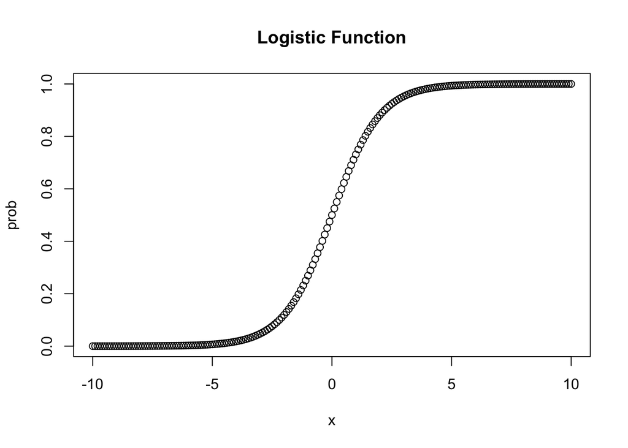

```r
x <- seq(-10, 10, by =0.1)
prob <- 1/(1+ exp(-x))
plot(x, prob, type = "b", main = "Logistic Function")
```

### 2.1.b Logistic Regression R Codes

Use gender as an example, we can interpret the regression result with odds ratio. Odds ratio: the ratio of the probability the event occurs to the probability it does not occur
$$odds = \frac{p}{1-p}$$
In this example the odds ratio percentage change is -21%, which means on average the odds of being a volunteer will diminish by 21% if the subject is male.

We can also get the predicted probability by the predict fucntion.

```r
#Load Cowles data from the effects package
#Explanation
help(Cowles)
```

```
## Help on topic 'Cowles' was found in the following packages:
##
##   Package               Library
##   effects               /Library/Frameworks/R.framework/Versions/3.3/Resources/library
##   car                   /Library/Frameworks/R.framework/Versions/3.3/Resources/library
##
##
## Using the first match ...
```

```r
mydata <- Cowles
summary(mydata)
```

```
##   neuroticism     extraversion       sex      volunteer
##  Min.   : 0.00   Min.   : 2.00   female:780   no :824
##  1st Qu.: 8.00   1st Qu.:10.00   male  :641   yes:597
##  Median :11.00   Median :13.00
##  Mean   :11.47   Mean   :12.37
##  3rd Qu.:15.00   3rd Qu.:15.00
##  Max.   :24.00   Max.   :23.00
```

```r
logit <- glm(formula = volunteer ~ neuroticism + sex + extraversion,
             data = mydata, family = binomial(link = "logit"))
summary(logit)
```

```
##
## Call:
## glm(formula = volunteer ~ neuroticism + sex + extraversion, family = binomial(link = "logit"),
##     data = mydata)
##
## Deviance Residuals:
##     Min       1Q   Median       3Q      Max
## -1.3977  -1.0454  -0.9084   1.2601   1.6849
##
## Coefficients:
##               Estimate Std. Error z value Pr(>|z|)
## (Intercept)  -1.116496   0.249057  -4.483 7.36e-06 ***
## neuroticism   0.006362   0.011357   0.560   0.5754
## sexmale      -0.235161   0.111185  -2.115   0.0344 *
## extraversion  0.066325   0.014260   4.651 3.30e-06 ***
## ---
## Signif. codes:  0 '***' 0.001 '**' 0.01 '*' 0.05 '.' 0.1 ' ' 1
##
## (Dispersion parameter for binomial family taken to be 1)
##
##     Null deviance: 1933.5  on 1420  degrees of freedom
## Residual deviance: 1906.1  on 1417  degrees of freedom
## AIC: 1914.1
##
## Number of Fisher Scoring iterations: 4
```

```r
#get odds ratio
100*(exp(logit$coefficients[-1])-1)
```

```
##  neuroticism      sexmale extraversion
##     0.638215   -20.955677     6.857438
```

```r
#prediction of a certain point
new <- data.frame(sex = "male", extraversion = 10, neuroticism =10)
predict(logit, newdata = new, type = 'response')
```

```
##        1
## 0.348694
```

```r
#we can also calculate the AIC by hand
#the formula is deviance + 2*(p+1), while p is the number of variables
aic <- logit$deviance+ 2*(4)
aic
```

```
## [1] 1914.061
```

- Lab Practice 1: based on the logistic funtion, can you get the predicted outcome with the coefficients given by the summary table?

```r
#we can compute the prediction by hand
y <- logit$coefficients[1]+ logit$coefficients[2]*10 + logit$coefficients[3]*1 + logit$coefficients[4]*10
#Then apply it to the logistic function
#logistic funtion is???
```

### 2.1.c Compare the results between logit and regular lm

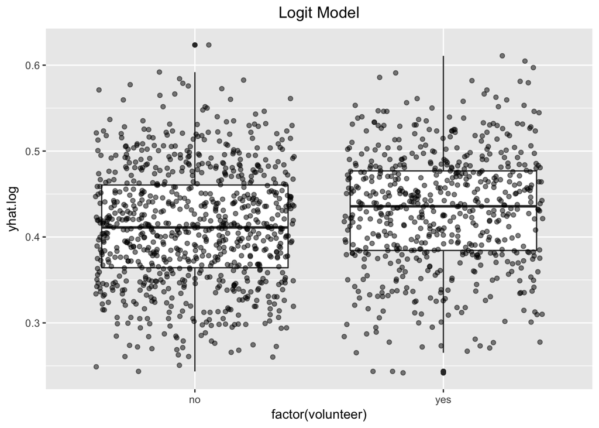

```r
yhat.log <- predict(logit, data=mydata, type = 'response')
lm <- lm(as.numeric(volunteer) ~ neuroticism + sex + extraversion, data = mydata)
yhat.lm <- predict(lm, data=mydata)
mydata$yhat.log <- yhat.log
mydata$yhat.lm  <- yhat.lm
ggplot(data = mydata, aes(factor(volunteer), yhat.log)) +
      geom_boxplot() +
      ggtitle("Logit Model") +
      geom_jitter(alpha = .5) +
      theme(plot.title = element_text(hjust = 0.5))
```

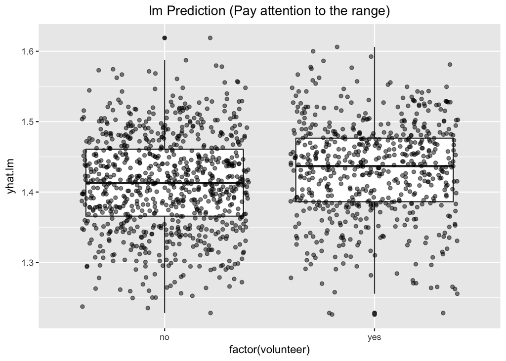

```r
ggplot(data = mydata, aes(factor(volunteer), yhat.lm)) +
      geom_boxplot() +
      geom_jitter(alpha = .5) +
      ggtitle("lm Prediction (Pay attention to the range)") +
      theme(plot.title = element_text(hjust = 0.5))
```

## 2.2 Probit Model

Probit model share the similar idea with logit model, but in the probit case we are doing a gaussian transformation (the CDF funtion of a standard normal distribution).

### 2.2.a Probit Function

It’s simply the CDF funtion of a standard normal distribution

$$\Phi(y) = \frac{1}{\sqrt{2\pi}}\int_{-\infty}^{y}e^{-t^2/2}dt$$
And y is the linear combination
$$y = XB = \beta_0 + \beta_1*x_1 + \beta_2*x_2 ...$$

```r
probit <- glm(formula = volunteer ~ neuroticism + sex + extraversion,
              data = mydata, family = binomial(link = "probit"))
summary(probit)
```

```
##
## Call:
## glm(formula = volunteer ~ neuroticism + sex + extraversion, family = binomial(link = "probit"),
##     data = mydata)
##
## Deviance Residuals:
##     Min       1Q   Median       3Q      Max
## -1.3947  -1.0468  -0.9091   1.2611   1.6901
##
## Coefficients:
##               Estimate Std. Error z value Pr(>|z|)
## (Intercept)  -0.692584   0.153670  -4.507 6.58e-06 ***
## neuroticism   0.004104   0.007044   0.583   0.5601
## sexmale      -0.145677   0.068957  -2.113   0.0346 *
## extraversion  0.040934   0.008790   4.657 3.21e-06 ***
## ---
## Signif. codes:  0 '***' 0.001 '**' 0.01 '*' 0.05 '.' 0.1 ' ' 1
##
## (Dispersion parameter for binomial family taken to be 1)
##
##     Null deviance: 1933.5  on 1420  degrees of freedom
## Residual deviance: 1906.1  on 1417  degrees of freedom
## AIC: 1914.1
##
## Number of Fisher Scoring iterations: 4
```

```r
#prediction of a certain point
new <- data.frame(sex = "male", extraversion = 10, neuroticism =10)
predict(probit, newdata = new, type = 'response')
```

```
##         1
## 0.3490514
```

- Lab Practice 2: pick another observation (you need to set values for sex, extraversion and neuroticism), compare the results of logit model and probit model.

# 3. Ordered Model

When our DV is an ordered/ranked outcome, such as ‘bad’, ‘ok’, ‘good’; or ‘unlikely’, ‘somewhat likely’, ‘very likely’, we need to use ordered model.

```r
mydata <- WVS
summary(mydata)
```

```
##         poverty     religion   degree          country          age
##  Too Little :2708   no : 786   no :4238   Australia:1874   Min.   :18.00
##  About Right:1862   yes:4595   yes:1143   Norway   :1127   1st Qu.:31.00
##  Too Much   : 811                         Sweden   :1003   Median :43.00
##                                           USA      :1377   Mean   :45.04
##                                                            3rd Qu.:58.00
##                                                            Max.   :92.00
##     gender
##  female:2725
##  male  :2656
##
##
##
##
```

```r
help(WVS)
#convert our DV to an ordered factor
mydata$poverty <- ordered(as.factor(mydata$poverty))
#change reference level to USA
mydata$country <- relevel(mydata$country, ref="USA")
#overview
table(mydata$poverty, mydata$country)
```

```
##
##               USA Australia Norway Sweden
##   Too Little  555       952    597    604
##   About Right 372       622    494    374
##   Too Much    450       300     36     25
```

## 3.1 Ordered Logit

```r
# the function y~. means regressing y on the rest variables
ologit <- polr(poverty ~., method = 'logistic', data = mydata)
summary(ologit)
```

```
##
## Re-fitting to get Hessian
```

```
## Call:
## polr(formula = poverty ~ ., data = mydata, method = "logistic")
##
## Coefficients:
##                     Value Std. Error t value
## religionyes       0.17973   0.077346   2.324
## degreeyes         0.14092   0.066193   2.129
## countryAustralia -0.61778   0.070665  -8.742
## countryNorway    -0.94012   0.078468 -11.981
## countrySweden    -1.22107   0.083957 -14.544
## age               0.01114   0.001561   7.139
## gendermale        0.17637   0.052972   3.329
##
## Intercepts:
##                        Value    Std. Error t value
## Too Little|About Right   0.1120   0.1134     0.9872
## About Right|Too Much     1.9147   0.1170    16.3719
##
## Residual Deviance: 10402.59
## AIC: 10420.59
```

### 3.1.b Ologit Interpretation

(Also see PA book p.114) Standard interpretation of the ordered logit coefficient is that for a one unit increase in the predictor, the response variable level is expected to change by its respective regression coefficient in the ordered log-odds scale while the other variables in the model are held constant. For instance, the religious `YES’ will increase the response variable level by am ordered log-odds scale of 0.179.

```r
100*(exp((ologit$coefficients))  -1)
```

```
##      religionyes        degreeyes countryAustralia    countryNorway
##        19.689369        15.132879       -46.085741       -60.941921
##    countrySweden              age       gendermale
##       -70.508524         1.120323        19.287748
```

Prediction can be done in a similar way with logit model.

```r
new <- data.frame(country = "Norway", religion = "no", age =50, degree="no", gender="female")
predict(ologit, newdata = new, type = "prob")
```

```
##  Too Little About Right    Too Much
##  0.62129816  0.28739457  0.09130727
```

# 4. Introduction of Zelig Project.

Website: [click here](http://docs.zeligproject.org/en/latest/vignette.html) Zelig allows a unified grammar in estimating generalized linear models, besides it provides an easy way of simulating probability distributions.

## 4.1 Logit Model

```r
mydata <- Cowles
zlogit <- zelig(volunteer ~neuroticism + sex + extraversion, model ="logit", data=mydata)
```

```
## How to cite this model in Zelig:
##   R Core Team. 2007.
##   logit: Logistic Regression for Dichotomous Dependent Variables
##   in Christine Choirat, Christopher Gandrud, James Honaker, Kosuke Imai, Gary King, and Olivia Lau,
##   "Zelig: Everyone's Statistical Software," http://zeligproject.org/
```

```r
summary(zlogit)
```

```
## Model:
##
## Call:
## z5$zelig(formula = volunteer ~ neuroticism + sex + extraversion,
##     data = mydata)
##
## Deviance Residuals:
##     Min       1Q   Median       3Q      Max
## -1.3977  -1.0454  -0.9084   1.2601   1.6849
##
## Coefficients:
##               Estimate Std. Error z value Pr(>|z|)
## (Intercept)  -1.116496   0.249057  -4.483 7.36e-06
## neuroticism   0.006362   0.011357   0.560   0.5754
## sexmale      -0.235161   0.111185  -2.115   0.0344
## extraversion  0.066325   0.014260   4.651 3.30e-06
##
## (Dispersion parameter for binomial family taken to be 1)
##
##     Null deviance: 1933.5  on 1420  degrees of freedom
## Residual deviance: 1906.1  on 1417  degrees of freedom
## AIC: 1914.1
##
## Number of Fisher Scoring iterations: 4
##
## Next step: Use 'setx' method
```

We can simulate the results by sim() and setx(). (Stata package clarify uses the same command, if you’re familar with Stata)

```r
x.zlogit <- setx(zlogit, sex="female", neuroticism = 10, extraversion =10)
zlogit.out <- sim(zlogit, x=x.zlogit)
summary(zlogit.out)
```

```
##
##  sim x :
##  -----
## ev
##           mean         sd       50%      2.5%     97.5%
## [1,] 0.4044184 0.02091127 0.4044213 0.3625772 0.4473622
## pv
##          0     1
## [1,] 0.597 0.403
```

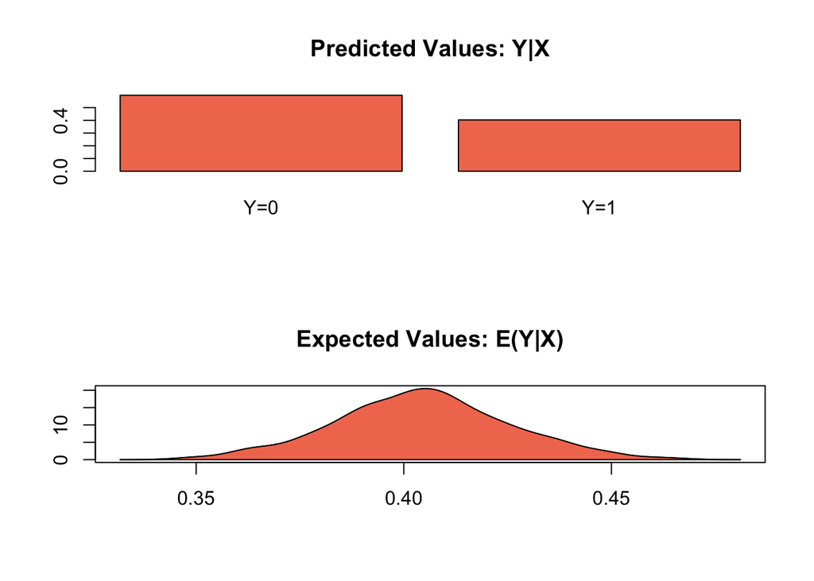

```r
plot(zlogit.out)
```

Use the similar logit we can calculate the differences at lower level Xs and higher level Xs.

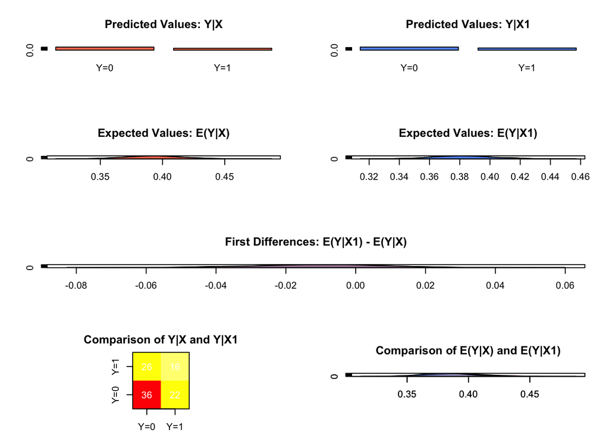

```r
#when not specified, other variables are held at mean level
x.high <- setx(zlogit, neuroticism = quantile(mydata$neuroticism, prob = 0.75), sex="male")
x.low <- setx(zlogit, neuroticism = quantile(mydata$neuroticism, prob = 0.25), sex="male")
s.out2 <- sim(zlogit, x = x.high, x1 = x.low)
plot(s.out2)
```

## 4.2 Ordered Logit Model

```r
#Load Data and make sure our DV is in ordered
mydata <- WVS
mydata$poverty <- factor(mydata$poverty, ordered = TRUE, levels = c("Too Little", "About Right", "Too Much"))
summary(mydata$poverty)
```

```
##  Too Little About Right    Too Much
##        2708        1862         811
```

```r
#change reference level to USA
mydata$country <- relevel(mydata$country, ref="USA")
```

Apply the Zelig Function

```r
z.ologit <- zelig(poverty ~ country + religion + age + degree, data=mydata, model="ologit")
```

```
## How to cite this model in Zelig:
##   William N. Venables, and Brian D. Ripley. 2011.
##   ologit: Ordinal Logit Regression for Ordered Categorical Dependent Variables
##   in Christine Choirat, Christopher Gandrud, James Honaker, Kosuke Imai, Gary King, and Olivia Lau,
##   "Zelig: Everyone's Statistical Software," http://zeligproject.org/
```

```r
summary(z.ologit)
```

```
## Model:
## Call:
## z5$zelig(formula = poverty ~ country + religion + age + degree,
##     data = mydata)
##
## Coefficients:
##                     Value Std. Error t value
## countryAustralia -0.61939   0.070641  -8.768
## countryNorway    -0.93825   0.078449 -11.960
## countrySweden    -1.21183   0.083853 -14.452
## religionyes       0.15614   0.076982   2.028
## age               0.01128   0.001559   7.233
## degreeyes         0.13634   0.066156   2.061
##
## Intercepts:
##                        Value    Std. Error t value
## Too Little|About Right   0.0109   0.1092     0.1002
## About Right|Too Much     1.8108   0.1125    16.0919
##
## Residual Deviance: 10413.69
## AIC: 10429.69
## Next step: Use 'setx' method
```

Set the explanatory variables to their observed values and simulate fitted values given x.out and view the results:

```r
x.out <- setx(z.ologit)
s.out <- sim(z.ologit, x = x.out)
summary(s.out)
```

```
##
##  sim x :
##  -----
## ev
##                  mean         sd       50%       2.5%     97.5%
## Too Little  0.4913076 0.01215966 0.4912377 0.46810957 0.5145733
## About Right 0.3608357 0.02712156 0.3612367 0.30552706 0.4138662
## Too Much    0.1478567 0.02502414 0.1469152 0.09939314 0.1958319
## pv
##       mean       sd 50% 2.5% 97.5%
## [1,] 1.653 0.726029   2    1     3
```

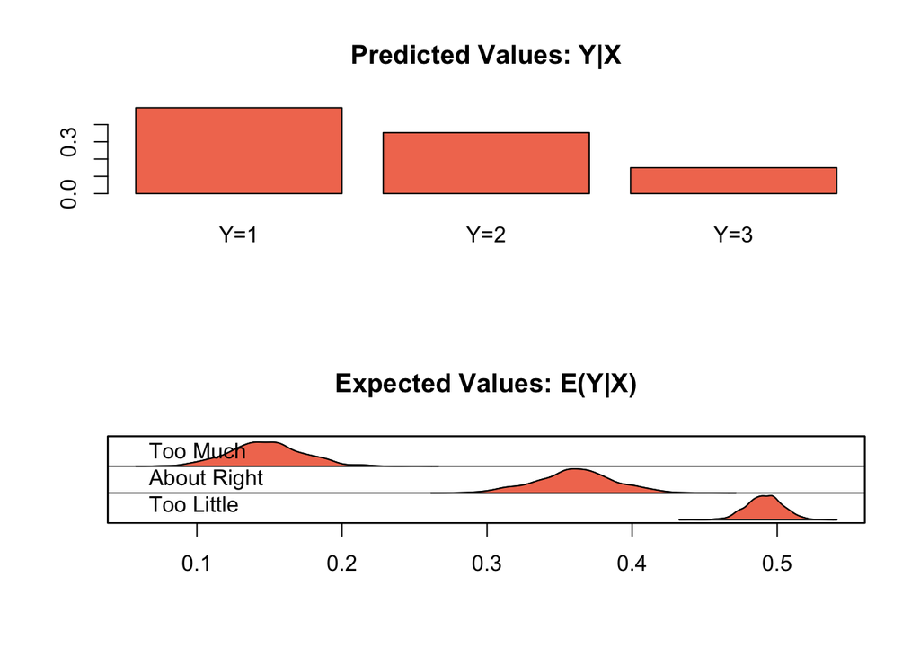

```r
plot(s.out)
```

## 4.3 Multinomial Logit Model

Multinomial logit model should be applied when our DV contains multiple nominal categories

We load the British Election Panel Study, in which the DV is the vote choice (Conservative, Labour and Liberal Democrat)

```r
#Load British Election Panel Study
mydata <- BEPS
summary(mydata)
```

```
##                vote          age        economic.cond.national
##  Conservative    :462   Min.   :24.00   Min.   :1.000
##  Labour          :720   1st Qu.:41.00   1st Qu.:3.000
##  Liberal Democrat:343   Median :53.00   Median :3.000
##                         Mean   :54.18   Mean   :3.246
##                         3rd Qu.:67.00   3rd Qu.:4.000
##                         Max.   :93.00   Max.   :5.000
##  economic.cond.household     Blair           Hague          Kennedy
##  Min.   :1.00            Min.   :1.000   Min.   :1.000   Min.   :1.000
##  1st Qu.:3.00            1st Qu.:2.000   1st Qu.:2.000   1st Qu.:2.000
##  Median :3.00            Median :4.000   Median :2.000   Median :3.000
##  Mean   :3.14            Mean   :3.334   Mean   :2.747   Mean   :3.135
##  3rd Qu.:4.00            3rd Qu.:4.000   3rd Qu.:4.000   3rd Qu.:4.000
##  Max.   :5.00            Max.   :5.000   Max.   :5.000   Max.   :5.000
##      Europe       political.knowledge    gender
##  Min.   : 1.000   Min.   :0.000       female:812
##  1st Qu.: 4.000   1st Qu.:0.000       male  :713
##  Median : 6.000   Median :2.000
##  Mean   : 6.729   Mean   :1.542
##  3rd Qu.:10.000   3rd Qu.:2.000
##  Max.   :11.000   Max.   :3.000
```